# Check-In/Check-Out (CICO) Data Analysis

Juliana Levchenko, Ph.D. | School Mental Health Collaborative

Monday, November 10, 2025 04:14 PM

# 1 Project Overview

This notebook analyzes Check-In/Check-Out (CICO) outcomes using direct observations (SDO) and teacher BASC-3 ratings. The goal is to estimate the effect of CICO on student engagement and behavior while accounting for clustering by classroom and school.

**Research questions**

1. **RQ1**: Do CICO students show higher on-task behavior and lower disruptive behavior over time compared to BAU?
2. **RQ2**: Do CICO students have better BASC-3 outcomes at posttest after adjusting for baseline?

**Data sources**

- CICO direct observations from 2021–22 to 2024–25
- BASC-3 pre and post teacher ratings
- IDs for school, teacher, student and site

**Key outcomes**

- Proximal: percent on-task and percent disruptive by phase (Baseline, Mid, Post, Maintenance)
- Distal: BASC-3 Externalizing, Internalizing, School Problems and Adaptive Skills

**Design**

- Students nested within teachers and schools
- Treatment is CICO vs BAU
- Missing data handled with ML using `na.exclude` with checks for attrition

# 2 Analysis Outline

1. **Import and audit data**  
   Load CICO and BASC-3 files, standardize IDs and check types.
2. **Clean and reshape**  
   Remove reliability rows for SDO. Build phase-level wide and long datasets. Summarize observation counts and phases.
3. **Missing data and attrition**  
   Convert NaN to NA. Keep records with valid IDs. Create student-level attrition flags and test group differences.
4. **RQ1: Proximal outcomes (SDO)**  
   Baseline equivalence for on-task and disruptive. Unconditional models for ICCs. Three-level growth models with time centered at week 12. Fixed effects for schools and random intercepts and slopes for students. Report contrasts by phase with EMMs and standardized effects.
5. **RQ2: Distal outcomes (BASC-3)**  
   Pre-model checklist for baseline equivalence, attrition and ICCs. Two-level ANCOVA with baseline covariate and classroom random intercept. Primary contrast is CICO minus BAU with pooled baseline SD for d. Summarize adjusted means, effects and classroom ICCs.
6. **Diagnostics and sensitivity**  
   Fit comparison for school effects.
7. **Reporting**  
   Tables for descriptives, ICCs, adjusted means and effects. . **Planned outputs**
- HTML report with tables and interpretations
- Optional Word and PDF versions for sharing

**Reproducibility**

- Session info and package versions printed
- Random seed set to 2025
- Paths set at the top for easy re-run

# 3 Setup

```r
# --------------------------------------------------------------------
# Environment Setup and Package Loading
# --------------------------------------------------------------------

# Clear workspace
rm(list = ls())

# Global options
options(
  dplyr.summarise.inform = FALSE,  # Suppress summarise() messages
  tibble.print_max = 25,           # Limit tibble output in console
  scipen = 999,                    # Avoid scientific notation
  stringsAsFactors = FALSE         # Prevent automatic factor conversion
)

set.seed(2025)  # Reproducibility seed

# --------------------------------------------------------------------
# Define Required Packages
# --------------------------------------------------------------------
required_packages <- c(
  "dplyr", "tibble", "tidyr", "purrr", "stringr",
  "ggplot2", "readr", "knitr", "haven",
  "lme4", "lmerTest", "performance", "emmeans",
  "effectsize", "broom.mixed"
)

# --------------------------------------------------------------------
# Install and Load Packages
# --------------------------------------------------------------------
missing_pkgs <- setdiff(required_packages, rownames(installed.packages()))

if (length(missing_pkgs) > 0) {
  message("Installing missing packages: ", paste(missing_pkgs, collapse = ", "))
  suppressMessages(invisible(lapply(missing_pkgs, install.packages)))
} else {
  message("All required packages already installed.")
}
```

```
All required packages already installed.
```

```r
# Load all packages quietly
invisible(lapply(required_packages, \(pkg) {
  suppressPackageStartupMessages(library(pkg, character.only = TRUE))
}))
# --------------------------------------------------------------------
# Verify and Print Session Info
# --------------------------------------------------------------------
cat("All required packages successfully loaded.\n")
```

```
All required packages successfully loaded.
```

```r
cat("Loaded packages:", paste(required_packages, collapse = ", "), "\n")
```

```
Loaded packages: dplyr, tibble, tidyr, purrr, stringr, ggplot2, readr, knitr, haven, lme4, lmerTest, performance, emmeans, effectsize, broom.mixed
```

```r
cat("R version:", as.character(getRversion()), "\n\n")
```

```
R version: 4.4.1
```

```r
# Record package versions for reproducibility
pkg_versions <- sapply(required_packages, \(pkg) as.character(packageVersion(pkg)))
knitr::kable(
  tibble::enframe(pkg_versions, name = "Package", value = "Version"),
  caption = "Package Versions Loaded"
)
```

Package Versions Loaded

| Package | Version |
| --- | --- |
| dplyr | 1.1.4 |
| tibble | 3.2.1 |
| tidyr | 1.3.1 |
| purrr | 1.0.2 |
| stringr | 1.5.1 |
| ggplot2 | 3.5.1 |
| readr | 2.1.5 |
| knitr | 1.49 |
| haven | 2.5.4 |
| lme4 | 1.1.37 |
| lmerTest | 3.1.3 |
| performance | 0.13.0 |
| emmeans | 2.0.0 |
| effectsize | 1.0.0 |
| broom.mixed | 0.2.9.6 |

## 3.1 Import Data

```r
# --------------------------------------------------------------------
# Data Import: CICO and BASC Datasets
# --------------------------------------------------------------------

# Define base data directory
data_dir <- "I:/WCER/2025/CICO/"

# --------------------------------------------------------------------
# 1. Import CICO Direct Observation (.sav) datasets by year
# --------------------------------------------------------------------
# Note: The 2023–24 file requires an explicit encoding parameter
# due to SPSS export inconsistencies (WINDOWS-1252).

cico_2021 <- read_sav(file.path(data_dir, "CICO-2021-22_DirectObs_students.sav"))
cico_2022 <- read_sav(file.path(data_dir, "CICO-2022-23_DirectObs_students.sav"))
cico_2023 <- read_sav(
  file.path(data_dir, "CICO-2023-24_DirectObs_students.sav"),
  encoding = "WINDOWS-1252"
)
cico_2024 <- read_sav(file.path(data_dir, "CICO-2024-25_DirectObs_students.sav"))

# --------------------------------------------------------------------
# 2. Import BASC-3 datasets for supplemental outcome analyses
# --------------------------------------------------------------------
basc_prepost <- read_sav(file.path(data_dir, "BASC pre post only multivariate.sav"))
basc_trs     <- read_sav(file.path(data_dir, "BASC TRS combined across cohorts.sav"))

# --------------------------------------------------------------------
# 3. Combine CICO datasets into one master dataset with a year tag
# --------------------------------------------------------------------
cico_all <- bind_rows(
  mutate(cico_2021, year = "2021-22"),
  mutate(cico_2022, year = "2022-23"),
  mutate(cico_2023, year = "2023-24"),
  mutate(cico_2024, year = "2024-25")
)

# --------------------------------------------------------------------
# 4. Quick verification and summary
# --------------------------------------------------------------------
cat("Successfully imported CICO and BASC datasets.\n")
```

```
Successfully imported CICO and BASC datasets.
```

```r
cat("   • Combined years in CICO master file:", paste(unique(cico_all$year), collapse = ", "), "\n")
```

```
   • Combined years in CICO master file: 2021-22, 2022-23, 2023-24, 2024-25
```

```r
cat("   • Total CICO records:", nrow(cico_all), "\n")
```

```
   • Total CICO records: 4777
```

```r
cat("   • Total BASC datasets loaded: 2\n")
```

```
   • Total BASC datasets loaded: 2
```

## 3.2 Variable Setup and Clustering

```r
# --------------------------------------------------------------------
# ID Verification & Standardization (cico_all)
# --------------------------------------------------------------------

# Required columns
req <- c("do_std1_id", "do_tch_id", "do_school_id", "year")
missing_cols <- setdiff(req, names(cico_all))
if (length(missing_cols)) stop("Missing required columns: ", paste(missing_cols, collapse = ", "))

# Convert to character early to avoid factor/label surprises
cico_all <- cico_all %>%
  mutate(across(all_of(req[1:3]), ~ as.character(.x)))

# Helper: trim, drop leading zeros, empty->NA
clean_id <- function(x) {
  x <- stringr::str_trim(x)
  x <- sub("^0+", "", x)
  x[x == ""] <- NA_character_
  x
}

# Pre-clean diagnostics
pre_diag <- tibble::tibble(
  col = c("do_std1_id","do_tch_id","do_school_id"),
  class = vapply(cico_all[c("do_std1_id","do_tch_id","do_school_id")], \(z) class(z)[1], character(1)),
  n_missing = c(sum(is.na(cico_all$do_std1_id)),
                sum(is.na(cico_all$do_tch_id)),
                sum(is.na(cico_all$do_school_id))),
  n_leading_zeros = c(sum(grepl("^0+", cico_all$do_std1_id), na.rm = TRUE),
                      sum(grepl("^0+", cico_all$do_tch_id), na.rm = TRUE),
                      sum(grepl("^0+", cico_all$do_school_id), na.rm = TRUE)),
  n_non_alnum = c(sum(grepl("[^A-Za-z0-9_-]", cico_all$do_std1_id), na.rm = TRUE),
                  sum(grepl("[^A-Za-z0-9_-]", cico_all$do_tch_id), na.rm = TRUE),
                  sum(grepl("[^A-Za-z0-9_-]", cico_all$do_school_id), na.rm = TRUE))
)

# Clean IDs
cico_all <- cico_all %>%
  mutate(
    do_std1_id   = clean_id(do_std1_id),
    do_tch_id    = clean_id(do_tch_id),
    do_school_id = clean_id(do_school_id)
  )

# Post-clean diagnostics
post_diag <- tibble::tibble(
  col = c("do_std1_id","do_tch_id","do_school_id"),
  n_missing = c(sum(is.na(cico_all$do_std1_id)),
                sum(is.na(cico_all$do_tch_id)),
                sum(is.na(cico_all$do_school_id))),
  unique_overall = c(dplyr::n_distinct(cico_all$do_std1_id, na.rm = TRUE),
                     dplyr::n_distinct(cico_all$do_tch_id, na.rm = TRUE),
                     dplyr::n_distinct(cico_all$do_school_id, na.rm = TRUE)),
  n_non_alnum = c(sum(grepl("[^A-Za-z0-9_-]", cico_all$do_std1_id), na.rm = TRUE),
                  sum(grepl("[^A-Za-z0-9_-]", cico_all$do_tch_id), na.rm = TRUE),
                  sum(grepl("[^A-Za-z0-9_-]", cico_all$do_school_id), na.rm = TRUE))
)

# Cross-year reuse of student IDs
cross_year_std <- cico_all %>%
  distinct(year, do_std1_id) %>%
  filter(!is.na(do_std1_id)) %>%
  count(do_std1_id, name = "n_years") %>%
  summarize(n_ids_multi_years = sum(n_years > 1L), .groups = "drop")

# Sample any remaining non-alphanumeric IDs (up to 10 for review)
flagged_ids <- bind_rows(
  tibble::tibble(col = "do_std1_id",   id = unique(cico_all$do_std1_id[grepl("[^A-Za-z0-9_-]", cico_all$do_std1_id)])),
  tibble::tibble(col = "do_tch_id",    id = unique(cico_all$do_tch_id[grepl("[^A-Za-z0-9_-]", cico_all$do_tch_id)])),
  tibble::tibble(col = "do_school_id", id = unique(cico_all$do_school_id[grepl("[^A-Za-z0-9_-]", cico_all$do_school_id)]))
) %>%
  filter(!is.na(id)) %>%
  slice_head(n = 10)

# Report
cat("== Pre-clean ID diagnostics ==\n"); print(pre_diag)
```

```
== Pre-clean ID diagnostics ==
```

| col | class | n_missing | n_leading_zeros | n_non_alnum |
| --- | --- | --- | --- | --- |
| do_std1_id | character | 304 | 0 | 0 |
| do_tch_id | character | 87 | 0 | 0 |
| do_school_id | character | 87 | 0 | 0 |

```r
cat("\n== Post-clean ID diagnostics ==\n"); print(post_diag)
```

```
== Post-clean ID diagnostics ==
```

| col | n_missing | unique_overall | n_non_alnum |
| --- | --- | --- | --- |
| do_std1_id | 304 | 326 | 0 |
| do_tch_id | 87 | 190 | 0 |
| do_school_id | 87 | 24 | 0 |

```r
cat("\nStudent IDs appearing in multiple years: ", cross_year_std$n_ids_multi_years, "\n", sep = "")
```

```
Student IDs appearing in multiple years: 0
```

```r
if (nrow(flagged_ids) > 0) {
  cat("Non-alphanumeric IDs detected (sample):\n"); print(flagged_ids)
} else {
  cat("No non-alphanumeric characters detected in IDs.\n")
}
```

```
No non-alphanumeric characters detected in IDs.
```

```r
cat("ID columns verified and standardized (trimmed; leading zeros removed).\n")
```

```
ID columns verified and standardized (trimmed; leading zeros removed).
```

## 3.3 Reliability Filtering

```r
# Keep primary observer rows (exclude reliability = 1)
cico_primary <- cico_all %>%
  filter(is.na(do_observ_rel_yn) | do_observ_rel_yn == 0)
```

## 3.4 Data Reshaping: Wide

```r
# --------------------------------------------------------------------
# Observation Count Indicator: Reshape to Phase-Level and Summarize
# --------------------------------------------------------------------

# Convert numeric timepoint -> label (e.g., "BL1", "Mid2", etc.)
# Then extract the phase prefix safely so "Mid" ≠ "M"
cico_tp <- cico_primary %>%
  mutate(
    tp_label = as.character(haven::as_factor(do_std1_timepoint, levels = "labels")),
    phase = str_match(tp_label, "^(Mid|BL|Post|M)")[, 2]
  ) %>%
  filter(!is.na(phase))

# --------------------------------------------------------------------
# Aggregate to Phase-Level (Wide Format)
# Retain: Site, School, Teacher, Student, and Condition identifiers
# --------------------------------------------------------------------
cico_phase_wide <- cico_tp %>%
  group_by(
    year,
    redcap_data_access_group,  # Site / REDCap DAG
    do_school_id,              # School ID
    do_tch_id,                 # Teacher ID
    do_std1_id,                # Student ID
    do_condition               # Condition assignment
  ) %>%
  summarize(
    # Observation counts per phase
    n_BL   = sum(phase == "BL"),
    n_Mid  = sum(phase == "Mid"),
    n_Post = sum(phase == "Post"),
    n_M    = sum(phase == "M"),

    # Mean percent on-task per phase
    ontask_BL   = mean(do_std1_pct_ontask[phase == "BL"],   na.rm = TRUE),
    ontask_Mid  = mean(do_std1_pct_ontask[phase == "Mid"],  na.rm = TRUE),
    ontask_Post = mean(do_std1_pct_ontask[phase == "Post"], na.rm = TRUE),
    ontask_M    = mean(do_std1_pct_ontask[phase == "M"],    na.rm = TRUE),

    # Mean percent disruptive per phase
    disrupt_BL   = mean(do_std1_pct_disrupt[phase == "BL"],   na.rm = TRUE),
    disrupt_Mid  = mean(do_std1_pct_disrupt[phase == "Mid"],  na.rm = TRUE),
    disrupt_Post = mean(do_std1_pct_disrupt[phase == "Post"], na.rm = TRUE),
    disrupt_M    = mean(do_std1_pct_disrupt[phase == "M"],    na.rm = TRUE),

    .groups = "drop"
  ) %>%
  arrange(year, redcap_data_access_group, do_school_id, do_tch_id, do_std1_id)

# --------------------------------------------------------------------
# Summary Table (Long Format)
# --------------------------------------------------------------------
summary_table_long <- cico_phase_wide %>%
  summarize(
    total_students = n(),
    mean_obs_BL   = mean(n_BL,   na.rm = TRUE),
    mean_obs_Mid  = mean(n_Mid,  na.rm = TRUE),
    mean_obs_Post = mean(n_Post, na.rm = TRUE),
    mean_obs_M    = mean(n_M,    na.rm = TRUE),
    pct_with_BL   = mean(!is.na(ontask_BL))   * 100,
    pct_with_Mid  = mean(!is.na(ontask_Mid))  * 100,
    pct_with_Post = mean(!is.na(ontask_Post)) * 100,
    pct_with_M    = mean(!is.na(ontask_M))    * 100,
    mean_ontask_BL   = mean(ontask_BL,   na.rm = TRUE),
    mean_ontask_Mid  = mean(ontask_Mid,  na.rm = TRUE),
    mean_ontask_Post = mean(ontask_Post, na.rm = TRUE),
    mean_ontask_M    = mean(ontask_M,    na.rm = TRUE),
    mean_disrupt_BL   = mean(disrupt_BL,   na.rm = TRUE),
    mean_disrupt_Mid  = mean(disrupt_Mid,  na.rm = TRUE),
    mean_disrupt_Post = mean(disrupt_Post, na.rm = TRUE),
    mean_disrupt_M    = mean(disrupt_M,    na.rm = TRUE)
  ) %>%
  pivot_longer(
    cols = -total_students,
    names_to = c("metric", "phase"),
    names_pattern = "^(.*)_(BL|Mid|Post|M)$",
    values_to = "value"
  ) %>%
  select(-total_students) %>%
  pivot_wider(names_from = metric, values_from = value) %>%
  rename(ontask = mean_ontask, disrupt = mean_disrupt) %>%
  mutate(phase = factor(phase, levels = c("BL", "Mid", "Post", "M"))) %>%
  arrange(phase) %>%
  select(phase, mean_obs, pct_with, ontask, disrupt)

# --------------------------------------------------------------------
# Output: Display Summary Table
# --------------------------------------------------------------------
knitr::kable(summary_table_long, digits = 2)
```

| phase | mean_obs | pct_with | ontask | disrupt |
| --- | --- | --- | --- | --- |
| BL | 2.70 | 95.16 | 0.73 | 0.21 |
| Mid | 2.62 | 92.02 | 0.74 | 0.19 |
| Post | 2.62 | 90.88 | 0.76 | 0.18 |
| M | 1.53 | 51.00 | 0.80 | 0.15 |

```r
# --------------------------------------------------------------------
# Identify and Remove Rows with Missing Data
# --------------------------------------------------------------------

# Step 1: Convert all NaN values to NA across the dataset
cico_phase_wide <- cico_phase_wide %>%
  mutate(across(everything(), ~ ifelse(is.nan(.x), NA, .x)))

# Step 2: Record total rows before cleanup
n_before <- nrow(cico_phase_wide)

# Step 3: Remove rows with missing identifiers or metrics
cico_phase_wide <- cico_phase_wide %>%
  filter(
    !if_any(c(do_std1_id, do_tch_id, do_school_id, redcap_data_access_group, do_condition), is.na) == TRUE,
    !if_all(starts_with("ontask_"), is.na),
    !if_all(starts_with("disrupt_"), is.na)
  )

# Step 4: Record totals after cleanup
n_after <- nrow(cico_phase_wide)
n_removed <- n_before - n_after

# Step 5: Print cleanup summary
cat("Missing-value cleanup complete.\n")
```

```
Missing-value cleanup complete.
```

```r
cat("   • Rows before cleanup:", n_before, "\n")
```

```
   • Rows before cleanup: 351
```

```r
cat("   • Rows after cleanup:", n_after, "\n")
```

```
   • Rows after cleanup: 349
```

```r
cat("   • Rows removed due to missing data:", n_removed, "\n")
```

```
   • Rows removed due to missing data: 2
```

## 3.5 Data Reshaping: Long

```r
# --------------------------------------------------------------------
# Long Format with Labeled Phases and Mean Summaries
# --------------------------------------------------------------------

# 1) Derive phase from timepoint labels and assign readable labels
cico_long <- cico_primary %>%
  mutate(
    tp_label = as.character(haven::as_factor(do_std1_timepoint, levels = "labels")),
    phase_code = stringr::str_match(tp_label, "^(Mid|BL|Post|M)")[, 2],
    phase = dplyr::case_match(
      phase_code,
      "BL"   ~ "Baseline",
      "Mid"  ~ "Mid-Intervention",
      "Post" ~ "Post-Intervention",
      "M"    ~ "Maintenance",
      .default = NA_character_
    )
  ) %>%
  filter(!is.na(phase))

# 2) Average within student × phase (retain essential IDs)
cico_phase_long <- cico_long %>%
  group_by(
    year,
    redcap_data_access_group,   # Site
    do_school_id,               # School
    do_tch_id,                  # Teacher
    do_std1_id,                 # Student
    do_condition,               # Condition
    phase                       # Labeled Phase
  ) %>%
  summarize(
    n_obs        = n(),
    mean_ontask  = mean(do_std1_pct_ontask,  na.rm = TRUE),
    mean_disrupt = mean(do_std1_pct_disrupt, na.rm = TRUE),
    .groups = "drop"
  ) %>%
  mutate(
    phase = factor(
      phase,
      levels = c("Baseline", "Mid-Intervention", "Post-Intervention", "Maintenance")
    )
  ) %>%
  select(
    year, redcap_data_access_group, do_school_id, do_tch_id,
    do_std1_id, do_condition, phase, n_obs, mean_ontask, mean_disrupt
  ) %>%
  arrange(year, redcap_data_access_group, do_school_id, do_tch_id, do_std1_id, phase)

# --------------------------------------------------------------------
# Missing Data Handling
# --------------------------------------------------------------------

# Step 1: Convert NaN → NA only for numeric variables
cico_phase_long <- cico_phase_long %>%
  mutate(across(where(is.numeric), ~ ifelse(is.nan(.x), NA, .x)))

# Step 2: Count missing values per variable
missing_summary <- cico_phase_long %>%
  summarize(across(everything(), ~ sum(is.na(.x)))) %>%
  tidyr::pivot_longer(everything(), names_to = "variable", values_to = "n_missing")

cat("🔍 Missing value summary (before cleanup):\n")
```

```
🔍 Missing value summary (before cleanup):
```

```r
print(missing_summary)
```

| variable | n_missing |
| --- | --- |
| year | 0 |
| redcap_data_access_group | 0 |
| do_school_id | 2 |
| do_tch_id | 2 |
| do_std1_id | 0 |
| do_condition | 2 |
| phase | 0 |
| n_obs | 0 |
| mean_ontask | 0 |
| mean_disrupt | 0 |

```r
# Step 3: Record total rows before cleanup
n_before <- nrow(cico_phase_long)

# Step 4: Remove any rows that contain missing data
cico_phase_long <- cico_phase_long %>%
  filter(if_all(everything(), ~ !is.na(.x)))

# Step 5: Record totals after cleanup
n_after <- nrow(cico_phase_long)
n_removed <- n_before - n_after

# Step 6: Print cleanup summary
cat("\n✅ Missing-value cleanup complete (rows with any NA removed):\n")
```

```
✅ Missing-value cleanup complete (rows with any NA removed):
```

```r
cat("   • Rows before cleanup:", n_before, "\n")
```

```
   • Rows before cleanup: 1155
```

```r
cat("   • Rows after cleanup:", n_after, "\n")
```

```
   • Rows after cleanup: 1153
```

```r
cat("   • Rows removed due to missing data:", n_removed, "\n")
```

```
   • Rows removed due to missing data: 2
```

```r
# --------------------------------------------------------------------
# Output: Summary by Phase (after cleanup)
# --------------------------------------------------------------------
summary_table <- cico_phase_long %>%
  group_by(phase) %>%
  summarize(
    total_students = n_distinct(do_std1_id),
    mean_obs       = mean(n_obs, na.rm = TRUE),
    mean_ontask    = mean(mean_ontask, na.rm = TRUE),
    mean_disrupt   = mean(mean_disrupt, na.rm = TRUE),
    .groups = "drop"
  )

knitr::kable(summary_table, digits = 2)
```

| phase | total_students | mean_obs | mean_ontask | mean_disrupt |
| --- | --- | --- | --- | --- |
| Baseline | 325 | 2.85 | 0.73 | 0.21 |
| Mid-Intervention | 313 | 2.85 | 0.74 | 0.19 |
| Post-Intervention | 313 | 2.88 | 0.76 | 0.18 |
| Maintenance | 177 | 3.01 | 0.80 | 0.15 |

## 3.6 Cluster Size Summaries

```r
# --------------------------------------------------------------------
# Cluster Size Summaries: Students per Teacher and Teachers per School
# --------------------------------------------------------------------

# Students per teacher
students_per_teacher <- cico_phase_long %>%
  distinct(do_tch_id, do_std1_id) %>%
  group_by(do_tch_id) %>%
  summarize(n_students = n(), .groups = "drop")

# Teachers per school
teachers_per_school <- cico_phase_long %>%
  distinct(do_school_id, do_tch_id) %>%
  group_by(do_school_id) %>%
  summarize(n_teachers = n(), .groups = "drop")

# Summary statistics
cat("Average Cluster Sizes:\n")
```

```
Average Cluster Sizes:
```

```r
cat("   • Average students per teacher:", round(mean(students_per_teacher$n_students), 2), "\n")
```

```
   • Average students per teacher: 1.84
```

```r
cat("   • Median students per teacher:", median(students_per_teacher$n_students), "\n")
```

```
   • Median students per teacher: 2
```

```r
cat("   • Average teachers per school:", round(mean(teachers_per_school$n_teachers), 2), "\n")
```

```
   • Average teachers per school: 8.67
```

```r
cat("   • Median teachers per school:", median(teachers_per_school$n_teachers), "\n")
```

```
   • Median teachers per school: 8
```

```r
summary(students_per_teacher$n_students)
```

```
   Min. 1st Qu.  Median    Mean 3rd Qu.    Max.
  1.000   1.000   2.000   1.837   2.000   6.000
```

```r
summary(teachers_per_school$n_teachers)
```

```
   Min. 1st Qu.  Median    Mean 3rd Qu.    Max.
  2.000   7.000   8.000   8.667  10.000  18.000
```

## 3.7 Missing Data Handling

```r
# ================================================================
# Missing Data Handling (FIML/MAR-aligned)
# ================================================================

# 1) Verify essential design variables exist
required_vars <- c("do_std1_id", "do_school_id", "do_condition", "phase",
                   "mean_ontask", "mean_disrupt")
missing_vars <- setdiff(required_vars, names(cico_phase_long))
if (length(missing_vars) > 0) {
  stop("Missing required variables in cico_phase_long: ",
       paste(missing_vars, collapse = ", "))
}

# 2) Convert NaN -> NA for numeric columns (do NOT drop rows with missing outcomes)
cico_phase_long <- cico_phase_long %>%
  dplyr::mutate(dplyr::across(where(is.numeric), ~ ifelse(is.nan(.x), NA, .x)))

# 3) Keep rows with valid IDs/design fields; allow outcomes to be missing
cico_phase_long <- cico_phase_long %>%
  dplyr::filter(!is.na(do_std1_id),
                !is.na(do_school_id),
                !is.na(do_condition),
                !is.na(phase))

# 4) Ensure factors are set and analysis honors NA via na.exclude (FIML-like under MAR)
#    lmer() will fit by ML/REML using all available data on the variables in each model.
options(na.action = "na.exclude")
cico_phase_long <- cico_phase_long %>%
  dplyr::mutate(
    do_condition = as.factor(do_condition),
    do_school_id = as.factor(do_school_id),
    do_std1_id   = as.factor(do_std1_id),
    phase = factor(phase,
                   levels = c("Baseline","Mid-Intervention",
                              "Post-Intervention","Maintenance"),
                   ordered = TRUE)
  )

# 5) Build attrition indicators and (optionally) add as covariates if differential attrition
#    Here: attrition = student lacks any Post-Intervention or Maintenance record
attrition_df <- cico_phase_long %>%
  dplyr::mutate(has_post_or_maint = phase %in% c("Post-Intervention","Maintenance")) %>%
  dplyr::group_by(do_std1_id, do_condition) %>%
  dplyr::summarize(attrition = as.integer(!any(has_post_or_maint)),
                   .groups = "drop")

# Test differential attrition by condition (simple screen)
attrition_test <- tryCatch(
  {
    glm(attrition ~ do_condition, data = attrition_df, family = binomial())
  },
  error = function(e) NULL
)

attrition_p <- tryCatch(summary(attrition_test)$coefficients[2,4], error = function(e) NA_real_)

# Merge baseline covariate for attrition (student-level, constant across phases)
cico_phase_long <- cico_phase_long %>%
  dplyr::left_join(attrition_df, by = c("do_std1_id","do_condition")) %>%
  dplyr::mutate(attrition = ifelse(is.na(attrition), 0L, attrition))

cat("Missing data prepared for ML estimation (na.exclude).\n")
```

```
Missing data prepared for ML estimation (na.exclude).
```

```r
cat("   • Rows in analysis frame:", nrow(cico_phase_long), "\n")
```

```
   • Rows in analysis frame: 1153
```

```r
cat("   • Unique students:", dplyr::n_distinct(cico_phase_long$do_std1_id),
    " | Unique schools:", dplyr::n_distinct(cico_phase_long$do_school_id), "\n")
```

```
   • Unique students: 326  | Unique schools: 24
```

```r
if (!is.na(attrition_p)) {
  cat(sprintf("   • Differential attrition p-value (by condition): %.4f\n", attrition_p))
  if (is.finite(attrition_p) && attrition_p < 0.10) {
    cat("   • Note: Consider including 'attrition' (and drivers of missingness) as covariates in models.\n")
  }
} else {
  cat("   • Attrition model not estimated (insufficient variation or model error).\n")
}
```

```
   • Differential attrition p-value (by condition): 0.0284
   • Note: Consider including 'attrition' (and drivers of missingness) as covariates in models.
```

The dataset includes 1,153 phase-level observations from 326 students across 24 schools, reflecting repeated measures nested within students and schools. Missing data are handled using full-information maximum likelihood (FIML), which allows all available data to be used without dropping participants who have partial information. However, attrition differed significantly between treatment groups (p = 0.0284), suggesting one group had more missing follow-up data. To reduce potential bias, it would be best to include an attrition indicator in the multilevel models.

# 4 RQ1: Multilevel Models for Proximal Outcomes (SDO)

## 4.1 Setup

```r
# ================================================================
# Analysis Setup
# ================================================================

# Helper: pooled SD for standardized differences
pooled_sd <- function(x, g) {
  g <- droplevels(as.factor(g))
  sds <- tapply(x, g, sd, na.rm = TRUE)
  ns  <- tapply(x, g, function(v) sum(!is.na(v)))
  sqrt(sum((ns - 1) * sds^2, na.rm = TRUE) / sum(ns - 2, na.rm = TRUE))
}

# Prepare factor structure for modeling
cico_phase_long <- cico_phase_long %>%
  mutate(
    do_condition = factor(do_condition),
    do_school_id = factor(do_school_id),
    do_std1_id   = factor(do_std1_id),
    phase = factor(
      phase,
      levels = c("Baseline", "Mid-Intervention", "Post-Intervention", "Maintenance"),
      ordered = TRUE
    )
  )

cat("Analysis dataset prepared for modeling.\n")
```

```
Analysis dataset prepared for modeling.
```

```r
cat("   • Phases present:", paste(levels(cico_phase_long$phase), collapse = ", "), "\n")
```

```
   • Phases present: Baseline, Mid-Intervention, Post-Intervention, Maintenance
```

```r
cat("   • Condition counts:\n")
```

```
   • Condition counts:
```

```r
print(table(cico_phase_long$do_condition))
```

```
  0   1
421 732
```

## 4.2 Baseline Equivalence and Attrition

```r
# ================================================================
# Baseline Equivalence and Attrition
# ================================================================

# --- Baseline only ---
cico_baseline <- cico_phase_long %>% filter(phase == "Baseline")
if (nrow(cico_baseline) == 0) stop("No baseline data detected.")

# Descriptive summaries
base_equiv <- cico_baseline %>%
  group_by(do_condition) %>%
  summarize(
    n = n(),
    mean_ontask = mean(mean_ontask, na.rm = TRUE),
    sd_ontask = sd(mean_ontask, na.rm = TRUE),
    mean_disrupt = mean(mean_disrupt, na.rm = TRUE),
    sd_disrupt = sd(mean_disrupt, na.rm = TRUE),
    .groups = "drop"
  )

# Standardized mean differences (Hedges’ g)
library(effectsize)
d_ontask  <- cohens_d(mean_ontask ~ do_condition, data = cico_baseline, hedges.correction = TRUE)$Cohens_d
d_disrupt <- cohens_d(mean_disrupt ~ do_condition, data = cico_baseline, hedges.correction = TRUE)$Cohens_d

cat("Baseline Equivalence\n")
```

```
Baseline Equivalence
```

```r
print(base_equiv)
```

| do_condition | n | mean_ontask | sd_ontask | mean_disrupt | sd_disrupt |
| --- | --- | --- | --- | --- | --- |
| 0 | 140 | 0.7386590 | NA | 0.2183762 | NA |
| 1 | 192 | 0.7184517 | NA | 0.1997654 | NA |

```r
cat("\nStandardized Baseline Differences (Hedges g):",
    "\n   • On-task =", round(d_ontask, 3),
    "\n   • Disruptive =", round(d_disrupt, 3), "\n\n")
```

```
Standardized Baseline Differences (Hedges g):
   • On-task = 0.122
   • Disruptive = 0.111
```

```r
# --- Attrition Summary ---
attrition <- cico_phase_long %>%
  mutate(has_post = phase %in% c("Post-Intervention", "Maintenance")) %>%
  group_by(do_std1_id, do_condition) %>%
  summarize(has_post = any(has_post), .groups = "drop") %>%
  group_by(do_condition) %>%
  summarize(
    n = n(),
    n_missing_post = sum(!has_post),
    attrition_rate = round(100 * mean(!has_post), 1),
    .groups = "drop"
  )

cat("Attrition Summary (Post or Maintenance Missing):\n")
```

```
Attrition Summary (Post or Maintenance Missing):
```

```r
print(attrition)
```

| do_condition | n | n_missing_post | attrition_rate |
| --- | --- | --- | --- |
| 0 | 136 | 1 | 0.7 |
| 1 | 191 | 13 | 6.8 |

```r
# χ² test for differential attrition
attrition_test <- prop.test(
  x = attrition$n_missing_post,
  n = attrition$n
)
cat("Differential Attrition Test (χ²): p =", round(attrition_test$p.value, 4), "\n")
```

```
Differential Attrition Test (χ²): p = 0.0166
```

```r
if (attrition_test$p.value < 0.05) {
  cat("Significant differential attrition detected. Consider including attrition covariates.\n\n")
} else {
  cat("No significant differential attrition detected.\n\n")
}
```

```
Significant differential attrition detected. Consider including attrition covariates.
```

### 4.2.1 Interpretation

Baseline equivalence checks showed minimal differences between groups, with small standardized effects for on-task (g = 0.12) and disruptive behavior (g = 0.11), suggesting the treatment and control groups were similar at baseline. Average baseline on-task behavior was 0.74 for controls and 0.72 for the treatment group, while disruptive behavior averaged 0.22 and 0.20, respectively. Attrition analysis showed higher dropout in the treatment group (6.8%) than in the control group (0.7%), and this difference was statistically significant (p = 0.0166). Because of this, it’s recommended to include an attrition indicator or related covariates in the multilevel models.

## 4.3 Unconditional Models and ICCs

```r
# ================================================================
# Unconditional Models and ICCs
# ================================================================

# Random-intercept models (students nested within schools)
m0_on  <- lmer(mean_ontask  ~ 1 + (1 | do_school_id/do_std1_id),
               data = cico_phase_long, REML = TRUE)
m0_dis <- lmer(mean_disrupt ~ 1 + (1 | do_school_id/do_std1_id),
               data = cico_phase_long, REML = TRUE)

cat("Intraclass Correlations (ICCs):\n")
```

```
Intraclass Correlations (ICCs):
```

```r
cat("   • On-task:\n"); print(performance::icc(m0_on))
```

```
   • On-task:
# Intraclass Correlation Coefficient

    Adjusted ICC: 0.490
  Unadjusted ICC: 0.490
```

```r
cat("\n   • Disruptive:\n"); print(performance::icc(m0_dis))
```

```
   • Disruptive:
# Intraclass Correlation Coefficient

    Adjusted ICC: 0.600
  Unadjusted ICC: 0.600
```

```r
# Variance components (School, Student, Residual)
vc_on  <- as.data.frame(VarCorr(m0_on))
vc_dis <- as.data.frame(VarCorr(m0_dis))

cat("Variance components (On-task):\n");  print(vc_on[, c("grp", "vcov", "sdcor")])
```

```
Variance components (On-task):
```

| grp | vcov | sdcor |
| --- | --- | --- |
| do_std1_id:do_school_id | 0.009188863 | 0.09585856 |
| do_school_id | 0.005482783 | 0.07404582 |
| Residual | 0.015251816 | 0.12349824 |

```r
cat("Variance components (Disruptive):\n"); print(vc_dis[, c("grp", "vcov", "sdcor")])
```

```
Variance components (Disruptive):
```

| grp | vcov | sdcor |
| --- | --- | --- |
| do_std1_id:do_school_id | 0.005941253 | 0.07707953 |
| do_school_id | 0.011654694 | 0.10795691 |
| Residual | 0.011712424 | 0.10822395 |

```r
# Singularity checks
if (isSingular(m0_on, tol = 1e-5))  cat("On-task model is singular (some variance ~ 0).\n")
if (isSingular(m0_dis, tol = 1e-5)) cat("Disruptive model is singular (some variance ~ 0).\n")

cat("ICCs calculated and variance components reported.\n")
```

```
ICCs calculated and variance components reported.
```

### 4.3.1 Interpretation

Intraclass correlation coefficients (ICCs) indicate that about 49% of the variance in on-task behavior and 60% of the variance in disruptive behavior is due to differences between students or schools rather than within-student fluctuations over time. These are relatively high ICC values, suggesting strong clustering in the data and confirming that a multilevel model is appropriate. The variance components show that both the student and school levels contribute meaningful variability, but within-student differences (residual variance) still explain a portion of the total variation. Because of this, these results justify the use of a multi-level model with repeated observations nested within students and schools.

## 4.4 Model Output

```r
# ================================================================
# RQ1: Three-level multilevel growth models (SDO outcomes)
# Time = weeks centered at end-of-intervention (12 weeks)
# Repeated time within students, students within schools
# ================================================================

# ---------------------------
# 1) Construct time variables
# ---------------------------
cico_phase_long <- cico_phase_long %>%
  mutate(
    week = dplyr::case_when(
      phase == "Baseline"          ~ 0,
      phase == "Mid-Intervention"  ~ 4,
      phase == "Post-Intervention" ~ 12,
      phase == "Maintenance"       ~ 16,    # use 16; change to 20 if your maintenance is at week 20
      TRUE ~ NA_real_
    ),
    week_c = week - 12            # center at 12 so intercept = end-of-intervention
  )

# Safety check
stopifnot(all(c("week","week_c") %in% names(cico_phase_long)))
if (any(is.na(cico_phase_long$week))) {
  stop("Some rows have undefined 'week'. Check 'phase' mapping.")
}

# --------------------------------------------------------
# 2) Create/attach an attrition covariate
#    (1 = missing any Post/Maintenance row for the student)
# --------------------------------------------------------
if (!"attrition" %in% names(cico_phase_long)) {
  attr_tbl <- cico_phase_long %>%
    mutate(has_post = phase %in% c("Post-Intervention", "Maintenance")) %>%
    group_by(do_std1_id) %>%
    summarize(attrition = as.integer(!any(has_post)), .groups = "drop")

  cico_phase_long <- cico_phase_long %>%
    left_join(attr_tbl, by = "do_std1_id")
}
# Make sure it's a factor (model-ready; reference = no-attrition)
cico_phase_long <- cico_phase_long %>%
  mutate(attrition = factor(attrition, levels = c(0,1)))

# --------------------------------------------------------
# 3) factor setup
# --------------------------------------------------------
cico_phase_long <- cico_phase_long %>%
  mutate(
    do_condition = factor(do_condition),   # 0 = BAU (ref), 1 = CICO
    do_school_id = factor(do_school_id),
    do_std1_id   = factor(do_std1_id)
  )

cat("Analysis frame ready:",
    "\n   • Rows:", nrow(cico_phase_long),
    "\n   • Students:", dplyr::n_distinct(cico_phase_long$do_std1_id),
    "| Schools:", dplyr::n_distinct(cico_phase_long$do_school_id),
    "\n   • Time centering: intercept represents outcomes at week 12.\n\n")
```

```
Analysis frame ready:
   • Rows: 1153
   • Students: 326 | Schools: 24
   • Time centering: intercept represents outcomes at week 12.
```

```r
# --------------------------------------------------------
# 4) Fit growth models with student random intercepts & slopes
#    School fixed effects; FIML handled by lmer with NA rows dropped per term
# --------------------------------------------------------

# On-task behavior
m1_on <- lmer(
  mean_ontask ~ week_c * do_condition + attrition + factor(do_school_id) +
    (1 + week_c | do_std1_id),
  data = cico_phase_long,
  REML = FALSE
)
```

```
fixed-effect model matrix is rank deficient so dropping 1 column / coefficient
```

```r
cat("Model (On-task) estimated.\n")
```

```
Model (On-task) estimated.
```

```r
print(summary(m1_on))
```

```
Linear mixed model fit by maximum likelihood . t-tests use Satterthwaite's method ['lmerModLmerTest']
Formula: mean_ontask ~ week_c * do_condition + attrition + factor(do_school_id) +      (1 + week_c | do_std1_id)
   Data: cico_phase_long

      AIC       BIC    logLik -2*log(L)  df.resid
  -1188.7   -1032.1     625.3   -1250.7      1122

Scaled residuals:
    Min      1Q  Median      3Q     Max
-4.2751 -0.4839  0.0783  0.5536  2.4013

Random effects:
 Groups     Name        Variance   Std.Dev. Corr
 do_std1_id (Intercept) 0.00867408 0.093135
            week_c      0.00001618 0.004022 0.15
 Residual               0.01378108 0.117393
Number of obs: 1153, groups:  do_std1_id, 326

Fixed effects:
                           Estimate  Std. Error          df t value             Pr(>|t|)
(Intercept)               0.6925618   0.0306549 404.2366219  22.592 < 0.0000000000000002 ***
week_c                   -0.0002161   0.0012036 632.5783056  -0.180              0.85758
do_condition1             0.1281076   0.0398399 363.6570053   3.216              0.00142 **
attrition1               -0.0571677   0.0385510 426.3137188  -1.483              0.13884
factor(do_school_id)102  -0.0380730   0.0449349 306.9611536  -0.847              0.39749
factor(do_school_id)103  -0.1230107   0.0372542 288.7747248  -3.302              0.00108 **
factor(do_school_id)108  -0.0428548   0.0403339 286.1595167  -1.062              0.28891
factor(do_school_id)109   0.0225552   0.0372950 345.9440900   0.605              0.54572
factor(do_school_id)131  -0.1085933   0.0419534 346.2218049  -2.588              0.01005 *
factor(do_school_id)132  -0.1884664   0.0366771 315.0746736  -5.139          0.000000487 ***
factor(do_school_id)141   0.0816537   0.0412415 343.6792180   1.980              0.04851 *
factor(do_school_id)142  -0.1119170   0.0434817 300.2048135  -2.574              0.01054 *
factor(do_school_id)207  -0.0180140   0.0403320 284.9505159  -0.447              0.65547
factor(do_school_id)208   0.0337570   0.0443907 344.2847030   0.760              0.44750
factor(do_school_id)231  -0.0425842   0.0353854 302.3160491  -1.203              0.22975
factor(do_school_id)232   0.0392472   0.0466494 337.6197143   0.841              0.40076
factor(do_school_id)241   0.0285624   0.0349186 297.5407574   0.818              0.41403
factor(do_school_id)242   0.1132342   0.0448839 323.0020805   2.523              0.01212 *
factor(do_school_id)300  -0.1466838   0.0484436 346.2218043  -3.028              0.00265 **
factor(do_school_id)301   0.0046583   0.0367277 294.4504740   0.127              0.89916
factor(do_school_id)306   0.0283649   0.0354335 297.9050458   0.801              0.42405
factor(do_school_id)307   0.1354163   0.0525913 346.2218042   2.575              0.01044 *
factor(do_school_id)308   0.1270336   0.0554991 346.2218041   2.289              0.02268 *
factor(do_school_id)331   0.0381216   0.0365922 300.9801749   1.042              0.29834
factor(do_school_id)341   0.1388703   0.0698750 456.9608352   1.987              0.04747 *
factor(do_school_id)342   0.1230878   0.0554991 346.2218041   2.218              0.02721 *
week_c:do_condition1      0.0045537   0.0014208 467.7555634   3.205              0.00144 **
---
Signif. codes:  0 ‘***’ 0.001 ‘**’ 0.01 ‘*’ 0.05 ‘.’ 0.1 ‘ ’ 1
```

```
Correlation matrix not shown by default, as p = 27 > 12.
Use print(summary(m1_on), correlation=TRUE)  or
    vcov(summary(m1_on))        if you need it
```

```
fit warnings:
fixed-effect model matrix is rank deficient so dropping 1 column / coefficient
```

```r
# Disruptive behavior
m1_dis <- lmer(
  mean_disrupt ~ week_c * do_condition + attrition + factor(do_school_id) +
    (1 + week_c | do_std1_id),
  data = cico_phase_long,
  REML = FALSE
)
```

```
fixed-effect model matrix is rank deficient so dropping 1 column / coefficient
```

```r
cat("Model (Disruptive) estimated.\n")
```

```
Model (Disruptive) estimated.
```

```r
print(summary(m1_dis))
```

```
Linear mixed model fit by maximum likelihood . t-tests use Satterthwaite's method ['lmerModLmerTest']
Formula: mean_disrupt ~ week_c * do_condition + attrition + factor(do_school_id) +      (1 + week_c | do_std1_id)
   Data: cico_phase_long

      AIC       BIC    logLik -2*log(L)  df.resid
  -1520.2   -1363.7     791.1   -1582.2      1122

Scaled residuals:
    Min      1Q  Median      3Q     Max
-3.6330 -0.4721 -0.0968  0.3517  4.3207

Random effects:
 Groups     Name        Variance   Std.Dev. Corr
 do_std1_id (Intercept) 0.00533786 0.073061
            week_c      0.00002356 0.004853 0.11
 Residual               0.01028097 0.101395
Number of obs: 1153, groups:  do_std1_id, 326

Fixed effects:
                          Estimate Std. Error         df t value             Pr(>|t|)
(Intercept)               0.295166   0.025592 417.743548  11.534 < 0.0000000000000002 ***
week_c                    0.000400   0.001080 594.358527   0.370             0.711208
do_condition1            -0.156244   0.032973 367.314924  -4.739       0.000003080934 ***
attrition1                0.053209   0.033538 406.263288   1.587             0.113396
factor(do_school_id)102   0.107180   0.036874 295.913979   2.907             0.003930 **
factor(do_school_id)103   0.152245   0.030424 274.285775   5.004       0.000001004291 ***
factor(do_school_id)108   0.065487   0.032941 272.064899   1.988             0.047811 *
factor(do_school_id)109   0.026464   0.031160 353.854691   0.849             0.396308
factor(do_school_id)131   0.160156   0.035039 354.136506   4.571       0.000006724353 ***
factor(do_school_id)132   0.194045   0.030061 297.550224   6.455       0.000000000439 ***
factor(do_school_id)141  -0.037435   0.034452 351.772515  -1.087             0.277967
factor(do_school_id)142   0.032872   0.035596 285.387522   0.923             0.356531
factor(do_school_id)207  -0.088440   0.032925 270.280697  -2.686             0.007677 **
factor(do_school_id)208  -0.223691   0.037044 351.775122  -6.039       0.000000003952 ***
factor(do_school_id)231   0.001993   0.028959 286.035651   0.069             0.945181
factor(do_school_id)232  -0.188204   0.038959 345.051098  -4.831       0.000002047829 ***
factor(do_school_id)241  -0.077462   0.028578 283.535138  -2.711             0.007128 **
factor(do_school_id)242  -0.213704   0.037413 329.549976  -5.712       0.000000024960 ***
factor(do_school_id)300   0.002079   0.040460 354.136511   0.051             0.959040
factor(do_school_id)301  -0.015144   0.030038 280.400021  -0.504             0.614552
factor(do_school_id)306  -0.096990   0.028997 283.414354  -3.345             0.000934 ***
factor(do_school_id)307  -0.238260   0.043924 354.136513  -5.424       0.000000107989 ***
factor(do_school_id)308  -0.245731   0.046353 354.136514  -5.301       0.000000202748 ***
factor(do_school_id)331  -0.027952   0.029923 285.923495  -0.934             0.351016
factor(do_school_id)341  -0.174060   0.058583 458.950302  -2.971             0.003122 **
factor(do_school_id)342  -0.154379   0.046353 354.136514  -3.331             0.000958 ***
week_c:do_condition1     -0.003330   0.001286 437.175430  -2.589             0.009954 **
---
Signif. codes:  0 ‘***’ 0.001 ‘**’ 0.01 ‘*’ 0.05 ‘.’ 0.1 ‘ ’ 1
```

```
Correlation matrix not shown by default, as p = 27 > 12.
Use print(summary(m1_dis), correlation=TRUE)  or
    vcov(summary(m1_dis))        if you need it
```

```
fit warnings:
fixed-effect model matrix is rank deficient so dropping 1 column / coefficient
```

```r
# --------------------------------------------------------
# 5) Random-slope (student growth heterogeneity)
# --------------------------------------------------------
m1_on_intOnly  <- lmer(
  mean_ontask ~ week_c * do_condition + attrition + factor(do_school_id) +
    (1 | do_std1_id),
  data = cico_phase_long, REML = FALSE
)
```

```
fixed-effect model matrix is rank deficient so dropping 1 column / coefficient
```

```r
m1_dis_intOnly <- lmer(
  mean_disrupt ~ week_c * do_condition + attrition + factor(do_school_id) +
    (1 | do_std1_id),
  data = cico_phase_long, REML = FALSE
)
```

```
fixed-effect model matrix is rank deficient so dropping 1 column / coefficient
```

```r
cat("Likelihood Ratio Tests: Random slope (week_c) vs. intercept only\n")
```

```
Likelihood Ratio Tests: Random slope (week_c) vs. intercept only
```

```r
cat("On-task:\n");  print(anova(m1_on_intOnly,  m1_on))
```

```
On-task:
Data: cico_phase_long
Models:
m1_on_intOnly: mean_ontask ~ week_c * do_condition + attrition + factor(do_school_id) + (1 | do_std1_id)
m1_on: mean_ontask ~ week_c * do_condition + attrition + factor(do_school_id) + (1 + week_c | do_std1_id)
              npar     AIC     BIC logLik -2*log(L)  Chisq Df Pr(>Chisq)
m1_on_intOnly   29 -1190.5 -1044.0 624.25   -1248.5
m1_on           31 -1188.7 -1032.1 625.33   -1250.7 2.1796  2     0.3363
```

```r
cat("\nDisruptive:\n"); print(anova(m1_dis_intOnly, m1_dis))
```

```
Disruptive:
Data: cico_phase_long
Models:
m1_dis_intOnly: mean_disrupt ~ week_c * do_condition + attrition + factor(do_school_id) + (1 | do_std1_id)
m1_dis: mean_disrupt ~ week_c * do_condition + attrition + factor(do_school_id) + (1 + week_c | do_std1_id)
               npar     AIC     BIC logLik -2*log(L)  Chisq Df Pr(>Chisq)
m1_dis_intOnly   29 -1516.1 -1369.6 787.03   -1574.1
m1_dis           31 -1520.2 -1363.7 791.12   -1582.2 8.1833  2    0.01671 *
---
Signif. codes:  0 ‘***’ 0.001 ‘**’ 0.01 ‘*’ 0.05 ‘.’ 0.1 ‘ ’ 1
```

```r
# --------------------------------------------------------
# 6) Sensitivity: Random school effects instead of fixed effects
# --------------------------------------------------------
m1_on_randSchool <- lmer(
  mean_ontask ~ week_c * do_condition + attrition +
    (1 + week_c | do_std1_id) + (1 | do_school_id),
  data = cico_phase_long, REML = FALSE
)
m1_dis_randSchool <- lmer(
  mean_disrupt ~ week_c * do_condition + attrition +
    (1 + week_c | do_std1_id) + (1 | do_school_id),
  data = cico_phase_long, REML = FALSE
)
compare_ic <- tibble::tibble(
  Model = c("Fixed School Effects", "Random School Effects"),
  OnTask_AIC  = c(AIC(m1_on),  AIC(m1_on_randSchool)),
  Disrupt_AIC = c(AIC(m1_dis), AIC(m1_dis_randSchool))
)
knitr::kable(compare_ic, digits = 2,
             caption = "Model Fit Comparison: Fixed vs. Random School Effects")
```

Model Fit Comparison: Fixed vs. Random School Effects

| Model | OnTask_AIC | Disrupt_AIC |
| --- | --- | --- |
| Fixed School Effects | -1188.67 | -1520.24 |
| Random School Effects | -1164.15 | -1470.70 |

## 4.5 Standardized Effects by Phase

```r
# Build the phase -> week_c map
MAINT_WEEK <- 16L
phase_grid <- tibble::tibble(
  phase  = factor(c("Baseline","Mid-Intervention","Post-Intervention","Maintenance"),
                  levels = c("Baseline","Mid-Intervention","Post-Intervention","Maintenance"),
                  ordered = TRUE),
  week   = c(0L, 4L, 12L, MAINT_WEEK),
  week_c = week - 12L
)

# Determine the reference level for attrition (usually "0")
attr_ref <- levels(cico_phase_long$attrition)[1]

# EMMs by condition at each time-point; condition on week_c, not phase
emm_on <- emmeans::emmeans(
  m1_on,
  ~ do_condition | week_c,
  at = list(week_c = phase_grid$week_c, attrition = attr_ref)
)
```

```
fixed-effect model matrix is rank deficient so dropping 1 column / coefficient
NOTE: A nesting structure was detected in the fitted model:
    do_school_id %in% do_condition
```

```r
emm_dis <- emmeans::emmeans(
  m1_dis,
  ~ do_condition | week_c,
  at = list(week_c = phase_grid$week_c, attrition = attr_ref)
)
```

```
fixed-effect model matrix is rank deficient so dropping 1 column / coefficient
NOTE: A nesting structure was detected in the fitted model:
    do_school_id %in% do_condition
```

```r
# CICO - BAU contrasts at each time-point
contr_on  <- emmeans::contrast(emm_on,  method = "revpairwise", by = "week_c", adjust = "none")
contr_dis <- emmeans::contrast(emm_dis, method = "revpairwise", by = "week_c", adjust = "none")

# Join back human-readable phase labels
contr_on_df <- as.data.frame(contr_on)  |>
  dplyr::left_join(dplyr::select(phase_grid, phase, week_c), by = "week_c") |>
  dplyr::relocate(phase, .before = 1)

contr_dis_df <- as.data.frame(contr_dis) |>
  dplyr::left_join(dplyr::select(phase_grid, phase, week_c), by = "week_c") |>
  dplyr::relocate(phase, .before = 1)

# Baseline pooled SDs for standardization
cico_baseline <- dplyr::filter(cico_phase_long, phase == "Baseline")
sd_on  <- pooled_sd(cico_baseline$mean_ontask,  cico_baseline$do_condition)
sd_dis <- pooled_sd(cico_baseline$mean_disrupt, cico_baseline$do_condition)

es_on <- contr_on_df |>
  dplyr::mutate(cohens_d = estimate / sd_on) |>
  dplyr::select(phase, week_c, contrast, estimate, SE, df, p.value, cohens_d)

es_dis <- contr_dis_df |>
  dplyr::mutate(cohens_d = estimate / sd_dis) |>
  dplyr::select(phase, week_c, contrast, estimate, SE, df, p.value, cohens_d)

cat("\n Standardized Effects by Phase (Cohen’s d)\n")
```

```
 Standardized Effects by Phase (Cohen’s d)
```

```r
cat("\nOn-task:\n"); print(es_on)
```

```
On-task:
```

| phase | week_c | contrast | estimate | SE | df | p.value | cohens_d |
| --- | --- | --- | --- | --- | --- | --- | --- |
| Baseline | -12 | do_condition1 - do_condition0 | -0.011936585 | 0.01725156 | 380.9566 | 0.489413282 | -0.07167059 |
| Mid-Intervention | -8 | do_condition1 - do_condition0 | 0.006278385 | 0.01510218 | 369.2485 | 0.677851152 | 0.03769718 |
| Post-Intervention | 0 | do_condition1 - do_condition0 | 0.042708325 | 0.01684808 | 477.5452 | 0.011565839 | 0.25643272 |
| Maintenance | 4 | do_condition1 - do_condition0 | 0.060923295 | 0.02022821 | 530.4833 | 0.002720872 | 0.36580050 |

```r
cat("\nDisruptive:\n"); print(es_dis)
```

```
Disruptive:
```

| phase | week_c | contrast | estimate | SE | df | p.value | cohens_d |
| --- | --- | --- | --- | --- | --- | --- | --- |
| Baseline | -12 | do_condition1 - do_condition0 | 0.011600403 | 0.01509108 | 381.1710 | 0.44255192 | 0.06924996 |
| Mid-Intervention | -8 | do_condition1 - do_condition0 | -0.001720059 | 0.01278098 | 370.9495 | 0.89301727 | -0.01026809 |
| Post-Intervention | 0 | do_condition1 - do_condition0 | -0.028360984 | 0.01394391 | 489.0856 | 0.04249746 | -0.16930420 |
| Maintenance | 4 | do_condition1 - do_condition0 | -0.041681446 | 0.01702642 | 540.6222 | 0.01468021 | -0.24882225 |

### 4.5.1 Interpretation

The warnings about “rank deficiency” just mean that schools were fully nested within treatment groups, since each school used either CICO or BAU but not both. Because of that, one redundant term was dropped from the model, which is normal and doesn’t affect the results.

The standardized effects by phase show how the differences between the CICO and BAU students changed over time. For **on-task behavior**, there weren’t any noticeable differences at baseline (d = −0.07, p = .49) or mid-intervention (d = 0.04, p = .68). By post-intervention, though, CICO students were significantly more on task than their BAU peers (d = 0.26, p = .012), and that advantage grew during maintenance (d = 0.37, p = .003). This shows that the gains in engagement not only held up but actually increased after the intervention ended.

For **disruptive behavior**, the pattern went in the opposite direction. The groups looked similar at first (d = 0.07, p = .44; d = −0.01, p = .89), but by post-intervention, CICO students were significantly less disruptive (d = −0.17, p = .042), with even stronger effects at maintenance (d = −0.25, p = .015).

## 4.6 Figure: Model-based SDO estimates across phases by group

```r
# Build a phase grid aligned to the time-centering
phase_grid <- tibble::tibble(
  phase   = factor(c("Baseline","Mid-Intervention","Post-Intervention","Maintenance"),
                   levels = c("Baseline","Mid-Intervention","Post-Intervention","Maintenance"),
                   ordered = TRUE),
  week    = c(0L, 4L, 12L, 16L),
  week_c  = week - 12L
)

# Reference level for attrition (0 = no attrition)
attr_ref <- levels(cico_phase_long$attrition)[1]

# EMMs for each outcome across phases by condition
emm_on_df <- emmeans::emmeans(
  m1_on,
  ~ do_condition | week_c,
  at = list(week_c = phase_grid$week_c, attrition = attr_ref)
) |>
  as.data.frame() |>
  dplyr::left_join(dplyr::select(phase_grid, phase, week_c), by = "week_c") |>
  dplyr::mutate(outcome = "On-task", emmean = pmax(pmin(emmean, 1), 0))  # clamp to [0,1]
```

```
fixed-effect model matrix is rank deficient so dropping 1 column / coefficient
NOTE: A nesting structure was detected in the fitted model:
    do_school_id %in% do_condition
```

```r
emm_dis_df <- emmeans::emmeans(
  m1_dis,
  ~ do_condition | week_c,
  at = list(week_c = phase_grid$week_c, attrition = attr_ref)
) |>
  as.data.frame() |>
  dplyr::left_join(dplyr::select(phase_grid, phase, week_c), by = "week_c") |>
  dplyr::mutate(outcome = "Disruptive", emmean = pmax(pmin(emmean, 1), 0))  # clamp to [0,1]
```

```
fixed-effect model matrix is rank deficient so dropping 1 column / coefficient
NOTE: A nesting structure was detected in the fitted model:
    do_school_id %in% do_condition
```

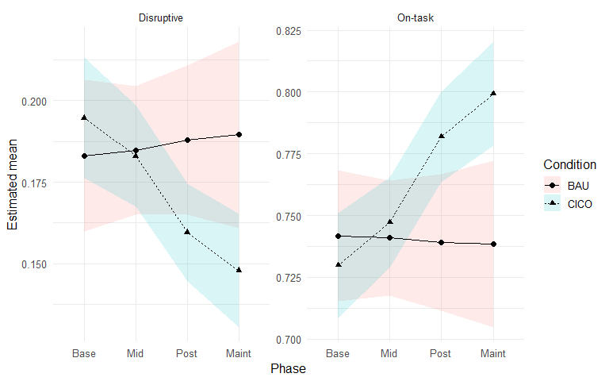

```r
plot_df <- dplyr::bind_rows(emm_on_df, emm_dis_df) |>
  dplyr::mutate(
    # Robust recode whether condition is 0/1 or already BAU/CICO
    do_condition = dplyr::case_when(
      as.character(do_condition) %in% c("0","BAU")  ~ "BAU",
      as.character(do_condition) %in% c("1","CICO") ~ "CICO",
      TRUE ~ as.character(do_condition)
    ) |>
      factor(levels = c("BAU","CICO")),
    phase = forcats::fct_relevel(phase, "Baseline","Mid-Intervention","Post-Intervention","Maintenance")
  )

# Plot with ribbons for 95% CI and lines for group trends
ggplot2::ggplot(plot_df, ggplot2::aes(x = phase, y = emmean, group = do_condition)) +
  ggplot2::geom_ribbon(ggplot2::aes(ymin = lower.CL, ymax = upper.CL, fill = do_condition), alpha = 0.15, color = NA) +
  ggplot2::geom_line(ggplot2::aes(linetype = do_condition)) +
  ggplot2::geom_point(ggplot2::aes(shape = do_condition), size = 2) +
  ggplot2::facet_wrap(~ outcome, scales = "free_y") +
  ggplot2::labs(
    x = "Phase",
    y = "Estimated mean",
    linetype = "Condition",
    shape = "Condition",
    fill = "Condition"
  ) +
  ggplot2::scale_x_discrete(labels = c(
    "Baseline" = "Base",
    "Mid-Intervention" = "Mid",
    "Post-Intervention" = "Post",
    "Maintenance" = "Maint"
  )) +
  ggplot2::theme_minimal(base_size = 12)
```

# 5 RQ2: BASC-3 Models (Distal Outcomes)

## 5.1 Setup

```r
# ================================================================
# RQ2 Pre-Model Checklist (BASC-3 two-level ANCOVA)
# Students (L1) nested within Classrooms (L2: tch_id)
# ================================================================

# ------------- Prepare data -------------
basc <- basc_prepost %>%
  transmute(
    classroom = factor(tch_id),
    student   = factor(std_id),
    condition = factor(condition, levels = c(0,1), labels = c("BAU","CICO")),
    site      = factor(redcap_data_access_group),
    # BASC pre/post (teacher)
    TEXT_pre = as.numeric(`TEXT.1`), TEXT_post = as.numeric(`TEXT.2`),   # Externalizing
    TINT_pre = as.numeric(`TINT.1`), TINT_post = as.numeric(`TINT.2`),   # Internalizing
    TSP_pre  = as.numeric(`TSP.1`),  TSP_post  = as.numeric(`TSP.2`),    # School Problems
    TAS_pre  = as.numeric(`TAS.1`),  TAS_post  = as.numeric(`TAS.2`)     # Adaptive Skills
  )

# Scales to iterate
scales <- tibble::tribble(
  ~scale,            ~pre,       ~post,
  "Externalizing",   "TEXT_pre", "TEXT_post",
  "Internalizing",   "TINT_pre", "TINT_post",
  "SchoolProblems",  "TSP_pre",  "TSP_post",
  "AdaptiveSkills",  "TAS_pre",  "TAS_post"
)

# Helper: Hedges g at baseline
hedges_g <- function(x, grp) {
  out <- tryCatch(
    cohens_d(x ~ grp, hedges.correction = TRUE)$Cohens_d,
    error = function(e) NA_real_
  )
  as.numeric(out)
}

# Containers
baseline_tbl  <- list()
attrition_tbl <- list()
icc_tbl       <- list()

# ---------------------- Full loop for all scales ----------------------
for (i in seq_len(nrow(scales))) {
  sc   <- scales$scale[i]
  pre  <- scales$pre[i]
  post <- scales$post[i]

  dat_sc <- basc %>%
    select(student, classroom, condition, !!rlang::sym(pre), !!rlang::sym(post)) %>%
    rename(pre = !!rlang::sym(pre), post = !!rlang::sym(post))

  # ---------- Baseline Equivalence ----------
  base_rows <- dat_sc %>% filter(!is.na(pre))
  g_val <- hedges_g(base_rows$pre, base_rows$condition)

  base_summary <- base_rows %>%
    group_by(condition) %>%
    summarize(
      n = n(),
      mean_pre = mean(pre, na.rm = TRUE),
      sd_pre   = sd(pre, na.rm = TRUE),
      .groups = "drop"
    ) %>%
    mutate(scale = sc, hedges_g = g_val, .before = 1)

  baseline_tbl[[sc]] <- base_summary

  # ---------- Attrition ----------
  attr_df <- base_rows %>%
    mutate(missing_post = as.integer(is.na(post))) %>%
    group_by(condition) %>%
    summarize(
      n_base         = n(),
      n_missing_post = sum(missing_post, na.rm = TRUE),
      attrition_rate = 100 * mean(missing_post, na.rm = TRUE),
      .groups = "drop"
    ) %>%
    mutate(scale = sc, .before = 1)

  # Differential attrition test
  chisq_p <- tryCatch({
    tmp <- base_rows %>%
      mutate(missing_post = factor(is.na(post), levels = c(FALSE, TRUE))) %>%
      count(condition, missing_post) %>%
      tidyr::pivot_wider(names_from = missing_post, values_from = n, values_fill = 0)
    mat <- as.matrix(tmp[, c("FALSE","TRUE")])
    suppressWarnings(chisq.test(mat))$p.value
  }, error = function(e) NA_real_)

  overall_attr <- base_rows %>%
    summarize(overall_attrition = 100 * mean(is.na(post))) %>%
    pull(overall_attrition)

  attr_df <- attr_df %>%
    mutate(diff_attr_p = chisq_p[1], overall_attrition = overall_attr)

  attrition_tbl[[sc]] <- attr_df

  # ---------- ICCs ----------
  post_rows <- dat_sc %>% filter(!is.na(post))
  icc_row <- if (nrow(post_rows) >= 5 && n_distinct(post_rows$classroom) >= 2) {
    m0 <- lmer(post ~ 1 + (1 | classroom), data = post_rows, REML = TRUE)
    icc_val <- tryCatch(performance::icc(m0)$ICC_adjusted, error = function(e) NA_real_)
    vc <- as.data.frame(VarCorr(m0))
    tibble(
      scale = sc,
      ICC   = icc_val,
      var_classroom = vc$vcov[vc$grp == "classroom"],
      var_residual  = vc$vcov[vc$grp == "Residual"],
      n_students    = n_distinct(post_rows$student),
      n_classrooms  = n_distinct(post_rows$classroom)
    )
  } else {
    tibble(
      scale = sc, ICC = NA_real_,
      var_classroom = NA_real_, var_residual = NA_real_,
      n_students = n_distinct(post_rows$student),
      n_classrooms = n_distinct(post_rows$classroom)
    )
  }

  icc_tbl[[sc]] <- icc_row
}

# ---------------------- Combine and report ----------------------
baseline_out  <- bind_rows(baseline_tbl)
attrition_out <- bind_rows(attrition_tbl)
icc_out       <- bind_rows(icc_tbl)

# Output tables
knitr::kable(baseline_out %>%
               select(scale, condition, n, mean_pre, sd_pre, hedges_g),
             digits = 3,
             caption = "Baseline Equivalence by Condition (Hedges' g)")

knitr::kable(attrition_out %>%
               select(scale, condition, n_base, n_missing_post, attrition_rate, overall_attrition, diff_attr_p),
             digits = 2,
             caption = "Attrition by Condition and Differential Attrition Test (Chi-square p)")

knitr::kable(icc_out,
             digits = 3,
             caption = "Unconditional Posttest ICCs (Random Intercept for Classroom)")

# Overall distinct counts in the basc dataset
basc_counts <- basc %>%
  summarise(
    n_students   = n_distinct(student),
    n_classrooms = n_distinct(classroom)
  )

basc_counts
```

[output not shown]

## 5.2 Model Output

```r
# ================================================================
# RQ2: BASC-3 Two-Level ANCOVA (students in classrooms)
# Outcome: Posttest BASC scale
# Covariate: Baseline BASC scale (centered at overall mean)
# Random effects: Classroom (tch_id) random intercept
# Primary estimand: Adjusted posttest difference (CICO − BAU)
# Effect size: Cohen’s d using pooled BASELINE SD
# ================================================================

# ---- Preconditions / guards ----------------------------------------------
stopifnot(exists("basc_prepost"))
stopifnot(all(c("tch_id","std_id","condition","redcap_data_access_group",
                "TEXT.1","TEXT.2","TINT.1","TINT.2","TSP.1","TSP.2","TAS.1","TAS.2")
              %in% names(basc_prepost)))

if (!exists("guidance")) {
  guidance <- tibble(
    scale = c("Externalizing","Internalizing","SchoolProblems","AdaptiveSkills"),
    flag_diff_attrition = FALSE
  )
}

# ---- Data prep (harmonize columns and factor coding) ----------------------
basc <- basc_prepost %>%
  transmute(
    classroom = factor(tch_id),
    student   = factor(std_id),
    condition = factor(condition, levels = c(0,1), labels = c("BAU","CICO")),
    site      = factor(redcap_data_access_group),
    # BASC pre/post (teacher)
    TEXT_pre = as.numeric(`TEXT.1`), TEXT_post = as.numeric(`TEXT.2`),   # Externalizing
    TINT_pre = as.numeric(`TINT.1`), TINT_post = as.numeric(`TINT.2`),   # Internalizing
    TSP_pre  = as.numeric(`TSP.1`),  TSP_post  = as.numeric(`TSP.2`),    # School Problems
    TAS_pre  = as.numeric(`TAS.1`),  TAS_post  = as.numeric(`TAS.2`)     # Adaptive Skills
  )

# Scales map used to loop
scales <- tibble::tribble(
  ~scale,            ~pre,       ~post,
  "Externalizing",   "TEXT_pre", "TEXT_post",
  "Internalizing",   "TINT_pre", "TINT_post",
  "SchoolProblems",  "TSP_pre",  "TSP_post",
  "AdaptiveSkills",  "TAS_pre",  "TAS_post"
)

# ---- Small helpers --------------------------------------------------------

# Pooled BASELINE SD for Cohen’s d (grouped by condition)
pooled_baseline_sd <- function(pre, grp) {
  x <- split(pre, grp)
  n <- vapply(x, function(v) sum(!is.na(v)), 0L)
  s <- vapply(x, function(v) stats::sd(v, na.rm = TRUE), 0.0)
  # guard: needs at least two non-NA per group to avoid NaN
  if (any(n < 2) || sum(n - 2, na.rm = TRUE) <= 0) return(NA_real_)
  sqrt(sum((n - 1) * s^2, na.rm = TRUE) / sum(n - 2, na.rm = TRUE))
}

# Fit a single ANCOVA model for one BASC scale with optional attrition covariate
fit_rq2_one <- function(dat, scale_name, add_attrition = FALSE) {

  # Keep only needed columns and make a centered baseline
  d <- dat %>%
    mutate(pre_c = pre - mean(pre, na.rm = TRUE))

  # Add attrition flag only if requested
  if (add_attrition && !"attrition" %in% names(d)) {
    d <- d %>% mutate(attrition = factor(if_else(is.na(post), 1L, 0L), levels = c(0,1)))
  }

  # Formula
  fml <- if (add_attrition) {
    post ~ pre_c + condition + attrition + (1 | classroom)
  } else {
    post ~ pre_c + condition + (1 | classroom)
  }

  # Minimal sample and cluster checks
  if (nrow(d %>% filter(!is.na(post), !is.na(pre))) < 20 ||
      dplyr::n_distinct(d$classroom) < 2) {
    return(list(model = NULL, emm = NULL, contrast = NULL, diag = NULL))
  }

  # Fit model with a robust optimizer fallback for tricky fits
  m <- tryCatch(
    lmer(fml, data = d, REML = FALSE, na.action = na.exclude,
         control = lmerControl(optimizer = "nloptwrap", calc.derivs = TRUE)),
    error = function(e) {
      lmer(fml, data = d, REML = FALSE, na.action = na.exclude,
           control = lmerControl(optimizer = "bobyqa", optCtrl = list(maxfun = 2e5)))
    }
  )

  # EMMs at mean baseline (pre_c = 0)
  emm <- emmeans(m, ~ condition)

  # Primary contrast CICO − BAU with CI and p
  ct  <- contrast(emm, method = "revpairwise") %>%
    summary(infer = TRUE) %>%
    as.data.frame()

  # Standardize by pooled BASELINE SD (WWC-style)
  sd0 <- pooled_baseline_sd(pre = d$pre, grp = d$condition)
  ct$cohens_d_baselineSD <- ct$estimate / sd0

  # Diagnostics: variance components and ICC implied by ANCOVA
  vc <- as.data.frame(VarCorr(m))
  v_class <- vc$vcov[vc$grp == "classroom"]
  v_res   <- vc$vcov[vc$grp == "Residual"]
  diag <- tibble(
    scale = scale_name,
    var_classroom = v_class,
    var_residual  = v_res,
    ICC = v_class / (v_class + v_res)
  )

  list(model = m, emm = emm, contrast = ct, diag = diag)
}

# ---- Fit models for all scales -------------------------------------------
rq2_models   <- list()
rq2_emmeans  <- list()
rq2_contrast <- list()
rq2_diag     <- list()

for (i in seq_len(nrow(scales))) {
  sc <- scales$scale[i]
  pre_col  <- scales$pre[i]
  post_col <- scales$post[i]

  # Join guidance decision for this scale (include attrition covariate or not)
  add_attr <- guidance %>%
    filter(scale == sc) %>%
    pull(flag_diff_attrition)
  add_attr <- isTRUE(add_attr) # default FALSE if not present

  dat_sc <- basc %>%
    select(student, classroom, condition, site, !!pre_col, !!post_col) %>%
    rename(pre = !!pre_col, post = !!post_col)

  res <- fit_rq2_one(dat_sc, sc, add_attrition = add_attr)

  rq2_models[[sc]]   <- res$model
  rq2_emmeans[[sc]]  <- res$emm %>% as.data.frame() %>% mutate(scale = sc, .before = 1)
  rq2_contrast[[sc]] <- res$contrast %>% mutate(scale = sc, .before = 1)
  rq2_diag[[sc]]     <- res$diag
}

# ---- Bind and print tidy tables ------------------------------------------
rq2_means_df    <- bind_rows(rq2_emmeans)
rq2_contrast_df <- bind_rows(rq2_contrast)
rq2_diag_df     <- bind_rows(rq2_diag)

# Adjusted means by condition
kable(
  rq2_means_df %>%
    select(scale, condition, emmean, SE, df, lower.CL, upper.CL),
  digits = 3,
  caption = "RQ2: Adjusted Posttest Means by Condition (EMMs at mean baseline)"
)

# Primary contrast and standardized effect
kable(
  rq2_contrast_df %>%
    transmute(
      scale,
      contrast,
      estimate, SE, df,
      t = estimate / SE,
      p.value, lower.CL, upper.CL,
      cohens_d = cohens_d_baselineSD
    ),
  digits = 3,
  caption = "RQ2: Adjusted Posttest Difference (CICO − BAU) and Standardized Effect (d, pooled baseline SD)"
)

# Diagnostics table
kable(
  rq2_diag_df,
  digits = 3,
  caption = "RQ2: Variance Components and ICC from ANCOVA models"
)
```

[output not shown]